# Electronidex Transactions

Salami Zainab

2024-07-31

# 1 LOADING LIBRARY

```r
library(arules)
library(arulesViz)
library("webshot2")
webshot::install_phantomjs()
```

# 2 INTRODUCTION

In this project, I perform a market basket analysis on transaction data from Electronidex, an online electronics retailer. The goal of this analysis is to uncover purchasing patterns and relationships between items that can offer insights into customer behavior.

The analysis will help Blackwell Electronics’ board of directors understand whether acquiring Electronidex would be a beneficial move. Key areas of focus include identifying interesting item associations, determining if Blackwell would benefit from selling Electronidex’s products, and providing recommendations on potential cross-selling opportunities, sales promotions, or product strategy post-acquisition.

By leveraging R, this project highlights how data-driven insights can inform strategic business decisions and optimize product offerings in the eCommerce sector.

# 3 LOADING DATASET

```r
#read.transactions(file("~/ElectronidexTransactions2017.csv"))
trans_df <- read.transactions("ElectronidexTransactions2017.csv", format = "basket", sep = ",", skip = 1)
```

# 4 DATA PREPROCESSING

## 4.1 Data Summary

In order to analyse the data in R, we use the summary function to see the useful information that will help us better understand the data

```r
#inspect(trans_df)
summary(trans_df)
```

```
## transactions as itemMatrix in sparse format with
##  9834 rows (elements/itemsets/transactions) and
##  125 columns (items) and a density of 0.03506203
##
## most frequent items:
##                     iMac                HP Laptop CYBERPOWER Gamer Desktop
##                     2519                     1909                     1809
##            Apple Earpods        Apple MacBook Air                  (Other)
##                     1715                     1530                    33618
##
## element (itemset/transaction) length distribution:
## sizes
##    0    1    2    3    4    5    6    7    8    9   10   11   12   13   14   15
##    2 2163 1647 1294 1020  856  646  540  439  353  247  171  119   77   72   56
##   16   17   18   19   20   21   22   23   25   26   27   29   30
##   41   26   20   10   10   10    5    3    1    1    3    1    1
##
##    Min. 1st Qu.  Median    Mean 3rd Qu.    Max.
##   0.000   2.000   3.000   4.383   6.000  30.000
##
## includes extended item information - examples:
##                             labels
## 1 1TB Portable External Hard Drive
## 2 2TB Portable External Hard Drive
## 3                   3-Button Mouse
```

or Looking at the frequency plot below, we got an insight to the best selling products and brand of Electronidex. The best selling products are Desktop, Laptops and Accessories. The best selling Brand is Apple.

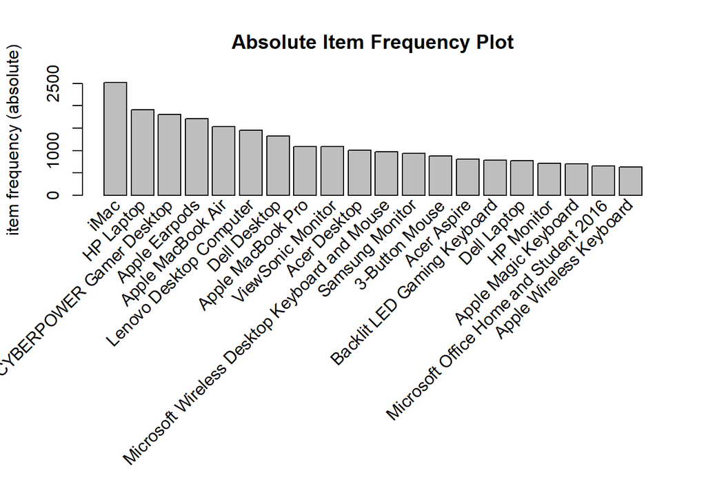

The table below shows the products with their respective counts.

```r
df <- as.data.frame(itemFrequency(trans_df, type = 'absolute'))
df <- cbind(Product = rownames(df), df)
rownames(df) <- 1:nrow(df)
colnames(df) <- c('Products', 'Count')
head(df)
```

```
##                           Products Count
## 1 1TB Portable External Hard Drive    27
## 2 2TB Portable External Hard Drive    60
## 3                   3-Button Mouse   875
## 4 3TB Portable External Hard Drive    68
## 5           5TB Desktop Hard Drive    41
## 6                      Acer Aspire   813
```

# 5 EXPLORATORY DATA ANALYSIS

## 5.1 Visualization to better understand the data

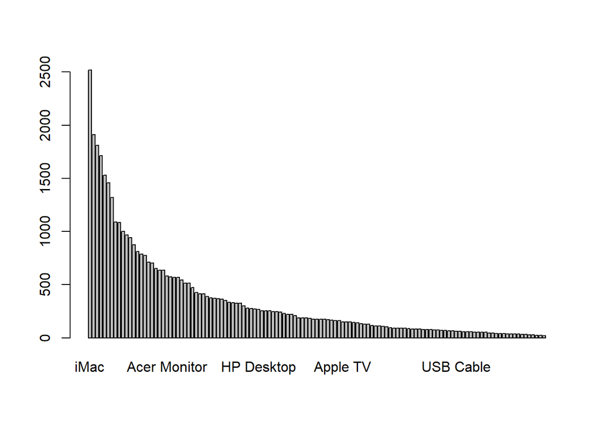

# 6 Create some rules

We use the Apriori algorithms in Arules library to minimize frequent itemsets and association rules. The algorithm employs level-wise search for frequent itemsets. We pass supp = 0.001 and con = 0.8 to return all the rules that have a support of at least 0.1% and confidence of at least 80%. We sort the rules by decreasing confidence. Lets take a look at the summary of the rules.

```r
rules <- apriori(trans_df, parameter = list(supp = 0.001, conf = 0.8))
```

```
## Apriori
##
## Parameter specification:
##  confidence minval smax arem  aval originalSupport maxtime support minlen
##         0.8    0.1    1 none FALSE            TRUE       5   0.001      1
##  maxlen target  ext
##      10  rules TRUE
##
## Algorithmic control:
##  filter tree heap memopt load sort verbose
##     0.1 TRUE TRUE  FALSE TRUE    2    TRUE
##
## Absolute minimum support count: 9
##
## set item appearances ...[0 item(s)] done [0.00s].
## set transactions ...[125 item(s), 9834 transaction(s)] done [0.00s].
## sorting and recoding items ... [125 item(s)] done [0.00s].
## creating transaction tree ... done [0.00s].
## checking subsets of size 1 2 3 4 5 6 done [0.01s].
## writing ... [635 rule(s)] done [0.00s].
## creating S4 object  ... done [0.00s].
```

```r
rules <- sort(rules, by = 'confidence', decreasing = TRUE)
summary(rules)
```

```
## set of 635 rules
##
## rule length distribution (lhs + rhs):sizes
##   3   4   5   6
##  30 303 269  33
##
##    Min. 1st Qu.  Median    Mean 3rd Qu.    Max.
##    3.00    4.00    4.00    4.48    5.00    6.00
##
## summary of quality measures:
##     support           confidence        coverage             lift
##  Min.   :0.001017   Min.   :0.8000   Min.   :0.001017   Min.   : 3.123
##  1st Qu.:0.001017   1st Qu.:0.8333   1st Qu.:0.001220   1st Qu.: 3.303
##  Median :0.001119   Median :0.8462   Median :0.001322   Median : 3.579
##  Mean   :0.001268   Mean   :0.8661   Mean   :0.001475   Mean   : 4.041
##  3rd Qu.:0.001322   3rd Qu.:0.9091   3rd Qu.:0.001627   3rd Qu.: 4.415
##  Max.   :0.005288   Max.   :1.0000   Max.   :0.006508   Max.   :10.080
##      count
##  Min.   :10.00
##  1st Qu.:10.00
##  Median :11.00
##  Mean   :12.47
##  3rd Qu.:13.00
##  Max.   :52.00
##
## mining info:
##      data ntransactions support confidence
##  trans_df          9834   0.001        0.8
##                                                                  call
##  apriori(data = trans_df, parameter = list(supp = 0.001, conf = 0.8))
```

The summary of the rules gives us some very interesting information: The number of the rules: 635 The distribution of rules by length: a length of 4 items has the most rules. The summary of quality measures: ranges of support, confidence, and lift. We have 635 rules. I don’t want to print them all, so let’s inspect the top 6

```r
inspect(head(rules))
```

```
##     lhs                                         rhs             support confidence    coverage     lift count
## [1] {Brother Printer,
##      Halter Acrylic Monitor Stand}           => {iMac}      0.001118568          1 0.001118568 3.903930    11
## [2] {ASUS Monitor,
##      Mackie CR Speakers,
##      ViewSonic Monitor}                      => {iMac}      0.001016880          1 0.001016880 3.903930    10
## [3] {Apple Magic Keyboard,
##      Rii LED Gaming Keyboard & Mouse Combo,
##      ViewSonic Monitor}                      => {iMac}      0.001728696          1 0.001728696 3.903930    17
## [4] {ASUS Monitor,
##      Koss Home Headphones,
##      Microsoft Office Home and Student 2016} => {iMac}      0.001016880          1 0.001016880 3.903930    10
## [5] {Acer Aspire,
##      Koss Home Headphones,
##      ViewSonic Monitor}                      => {HP Laptop} 0.001220256          1 0.001220256 5.151388    12
## [6] {Dell Desktop,
##      Koss Home Headphones,
##      ViewSonic Monitor}                      => {HP Laptop} 0.001118568          1 0.001118568 5.151388    11
```

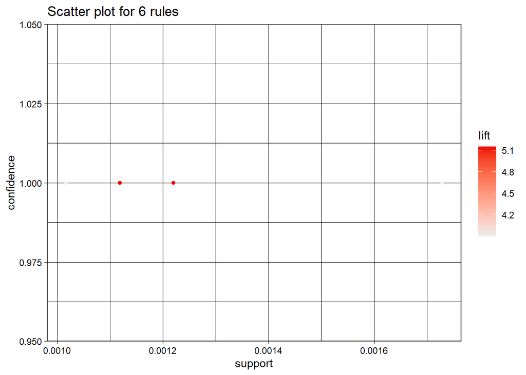

```r
plot(rules[1:6], jitter = 0)
```

The scatterplot above shows the distribution of the six top rules generated from all products transactions: we can see the presence of few rules with high confidence and lift. But there’s a way to produce better performing rules by adjusting the support confidence of the rules

Below is some output showing the top 6 rules found sorted by highest confidence. We can also perform redundancy check to remove any low tier ruleset.

```r
rules_conf <- sort(rules, by = 'confidence', decreasing = TRUE)
# 'high confidence' rules,
inspect(head(rules_conf)) # show the support, lift and confidence for 6 rules
```

```
##     lhs                                         rhs             support confidence    coverage     lift count
## [1] {Brother Printer,
##      Halter Acrylic Monitor Stand}           => {iMac}      0.001118568          1 0.001118568 3.903930    11
## [2] {ASUS Monitor,
##      Mackie CR Speakers,
##      ViewSonic Monitor}                      => {iMac}      0.001016880          1 0.001016880 3.903930    10
## [3] {Apple Magic Keyboard,
##      Rii LED Gaming Keyboard & Mouse Combo,
##      ViewSonic Monitor}                      => {iMac}      0.001728696          1 0.001728696 3.903930    17
## [4] {ASUS Monitor,
##      Koss Home Headphones,
##      Microsoft Office Home and Student 2016} => {iMac}      0.001016880          1 0.001016880 3.903930    10
## [5] {Acer Aspire,
##      Koss Home Headphones,
##      ViewSonic Monitor}                      => {HP Laptop} 0.001220256          1 0.001220256 5.151388    12
## [6] {Dell Desktop,
##      Koss Home Headphones,
##      ViewSonic Monitor}                      => {HP Laptop} 0.001118568          1 0.001118568 5.151388    11
```

# 7 PRUNNING RULES

## 7.1 Controlling max length of product in a transaction

```r
rules_maxlength_3 <- apriori(trans_df, parameter = list(supp = 0.002, conf = 0.7, maxlen = 3))
```

```
## Apriori
##
## Parameter specification:
##  confidence minval smax arem  aval originalSupport maxtime support minlen
##         0.7    0.1    1 none FALSE            TRUE       5   0.002      1
##  maxlen target  ext
##       3  rules TRUE
##
## Algorithmic control:
##  filter tree heap memopt load sort verbose
##     0.1 TRUE TRUE  FALSE TRUE    2    TRUE
##
## Absolute minimum support count: 19
##
## set item appearances ...[0 item(s)] done [0.00s].
## set transactions ...[125 item(s), 9834 transaction(s)] done [0.00s].
## sorting and recoding items ... [125 item(s)] done [0.00s].
## creating transaction tree ... done [0.00s].
## checking subsets of size 1 2 3
```

```
##  done [0.00s].
## writing ... [23 rule(s)] done [0.00s].
## creating S4 object  ... done [0.00s].
```

## 7.2 Items that lead to iMac

We are looking at items that lead to iMac

```r
rules<- apriori(data=trans_df, parameter=list(supp=0.002,conf = 0.6),
                appearance = list(default="lhs", rhs = "iMac"),
                control = list(verbose = F))

sortedrules<-sort(rules, by = "lift", decreasing = TRUE)
inspect(sortedrules[1:5])
```

```
##     lhs                                         rhs        support confidence    coverage     lift count
## [1] {Dell Desktop,
##      Mackie CR Speakers}                     => {iMac} 0.002643889  0.8666667 0.003050641 3.383406    26
## [2] {ASUS Monitor,
##      HP Laptop,
##      LG Monitor}                             => {iMac} 0.002237136  0.8461538 0.002643889 3.303325    22
## [3] {Acer Desktop,
##      Apple Magic Keyboard,
##      ASUS Monitor}                           => {iMac} 0.002237136  0.8461538 0.002643889 3.303325    22
## [4] {ASUS 2 Monitor,
##      Dell Desktop,
##      Microsoft Office Home and Student 2016} => {iMac} 0.002440513  0.8275862 0.002948953 3.230839    24
## [5] {Apple Magic Keyboard,
##      Dell Desktop,
##      Microsoft Office Home and Student 2016} => {iMac} 0.002440513  0.8275862 0.002948953 3.230839    24
```

## 7.3 Controlling min length of product in a transaction

Items that are bought with iMac

```r
rules_iMac<-apriori(data=trans_df, parameter = list(supp=0.002, conf = 0.15, minlen = 2),
                    appearance = list(default = "rhs", lhs = "iMac"),
                    control = list(verbose=F))
```

```r
summary(rules_iMac)
```

```
## set of 6 rules
##
## rule length distribution (lhs + rhs):sizes
## 2
## 6
##
##    Min. 1st Qu.  Median    Mean 3rd Qu.    Max.
##       2       2       2       2       2       2
##
## summary of quality measures:
##     support          confidence        coverage           lift
##  Min.   :0.04027   Min.   :0.1572   Min.   :0.2562   Min.   :0.9014
##  1st Qu.:0.05072   1st Qu.:0.1980   1st Qu.:0.2562   1st Qu.:1.2830
##  Median :0.05567   Median :0.2173   Median :0.2562   Median :1.5346
##  Mean   :0.05589   Mean   :0.2182   Mean   :0.2562   Mean   :1.4190
##  3rd Qu.:0.05827   3rd Qu.:0.2275   3rd Qu.:0.2562   3rd Qu.:1.5804
##  Max.   :0.07555   Max.   :0.2950   Max.   :0.2562   Max.   :1.7487
##      count
##  Min.   :396.0
##  1st Qu.:498.8
##  Median :547.5
##  Mean   :549.7
##  3rd Qu.:573.0
##  Max.   :743.0
##
## mining info:
##      data ntransactions support confidence
##  trans_df          9834   0.002       0.15
##                                                                                                                                                              call
##  apriori(data = trans_df, parameter = list(supp = 0.002, conf = 0.15, minlen = 2), appearance = list(default = "rhs", lhs = "iMac"), control = list(verbose = F))
```

```r
sortedrules<-sort(rules_iMac, by = 'lift', decreasing = TRUE)
inspect(sortedrules[1:6])
```

```
##     lhs       rhs                        support    confidence coverage
## [1] {iMac} => {ViewSonic Monitor}        0.04942038 0.1929337  0.2561521
## [2] {iMac} => {Dell Desktop}             0.05460647 0.2131798  0.2561521
## [3] {iMac} => {Lenovo Desktop Computer}  0.05877568 0.2294561  0.2561521
## [4] {iMac} => {HP Laptop}                0.07555420 0.2949583  0.2561521
## [5] {iMac} => {CYBERPOWER Gamer Desktop} 0.05674192 0.2215165  0.2561521
## [6] {iMac} => {Apple Earpods}            0.04026846 0.1572052  0.2561521
##     lift      count
## [1] 1.7486729 486
## [2] 1.5905998 537
## [3] 1.5497745 578
## [4] 1.5194448 743
## [5] 1.2041974 558
## [6] 0.9014323 396
```

```r
plot(rules_iMac, method = 'graph', engine = 'htmlwidget')
```

[interactive chart not shown]

What we see in the above rules is that when a customer buys an iMac most of the times with 29.5% confidence the customer also buys HP Laptop or with 22.9% confidence the customer buy Lenovo Desktop Computer. More specifically these two items that are purchased at the same time are iMac with HP Laptop or iMac with Dell Desktop or iMac with ViewSonic Monitor or iMac with Apple Earpods or iMac with CYBERPOWER Gamer Desktop or iMac with Lenovo Desktop Computer. The purchase of iMac with HP Laptop seems to be more general because it happened 743 times out of the 9834 total transactions.

```r
rules_Apple_Macbook_Air<-apriori(data=trans_df,
                                 parameter = list(supp=0.002, conf = 0.15, minlen = 2),
                                 appearance = list(default = "rhs", lhs = "Apple MacBook Air"),
                                 control = list(verbose=F))
```

```r
summary(rules_Apple_Macbook_Air)
```

```
## set of 4 rules
##
## rule length distribution (lhs + rhs):sizes
## 2
## 4
##
##    Min. 1st Qu.  Median    Mean 3rd Qu.    Max.
##       2       2       2       2       2       2
##
## summary of quality measures:
##     support          confidence        coverage           lift
##  Min.   :0.02410   Min.   :0.1549   Min.   :0.1556   Min.   :0.7144
##  1st Qu.:0.02410   1st Qu.:0.1549   1st Qu.:0.1556   1st Qu.:0.7771
##  Median :0.02629   Median :0.1690   Median :0.1556   Median :0.8200
##  Mean   :0.02667   Mean   :0.1714   Mean   :0.1556   Mean   :0.8650
##  3rd Qu.:0.02885   3rd Qu.:0.1855   3rd Qu.:0.1556   3rd Qu.:0.9080
##  Max.   :0.03000   Max.   :0.1928   Max.   :0.1556   Max.   :1.1056
##      count
##  Min.   :237.0
##  1st Qu.:237.0
##  Median :258.5
##  Mean   :262.2
##  3rd Qu.:283.8
##  Max.   :295.0
##
## mining info:
##      data ntransactions support confidence
##  trans_df          9834   0.002       0.15
##                                                                                                                                                                           call
##  apriori(data = trans_df, parameter = list(supp = 0.002, conf = 0.15, minlen = 2), appearance = list(default = "rhs", lhs = "Apple MacBook Air"), control = list(verbose = F))
```

```r
plot(rules_Apple_Macbook_Air, method = "graph", engine = "htmlwidget")
```

[interactive chart not shown]

```r
rules_Lenovo_Desktop_Computer <- apriori(data=trans_df, parameter = list(supp=0.001, conf = 0.15, minlen = 2),
                                         appearance = list(default = "rhs", lhs = "Lenovo Desktop Computer"),
                                         control = list(verbose=F))
summary(rules_Lenovo_Desktop_Computer)
```

```
## set of 9 rules
##
## rule length distribution (lhs + rhs):sizes
## 2
## 9
##
##    Min. 1st Qu.  Median    Mean 3rd Qu.    Max.
##       2       2       2       2       2       2
##
## summary of quality measures:
##     support          confidence        coverage           lift
##  Min.   :0.02247   Min.   :0.1518   Min.   :0.1481   Min.   :1.107
##  1st Qu.:0.02400   1st Qu.:0.1621   1st Qu.:0.1481   1st Qu.:1.466
##  Median :0.02857   Median :0.1930   Median :0.1481   Median :1.550
##  Mean   :0.03381   Mean   :0.2283   Mean   :0.1481   Mean   :1.557
##  3rd Qu.:0.03671   3rd Qu.:0.2479   3rd Qu.:0.1481   3rd Qu.:1.737
##  Max.   :0.05878   Max.   :0.3970   Max.   :0.1481   Max.   :1.850
##      count
##  Min.   :221.0
##  1st Qu.:236.0
##  Median :281.0
##  Mean   :332.4
##  3rd Qu.:361.0
##  Max.   :578.0
##
## mining info:
##      data ntransactions support confidence
##  trans_df          9834   0.001       0.15
##                                                                                                                                                                                 call
##  apriori(data = trans_df, parameter = list(supp = 0.001, conf = 0.15, minlen = 2), appearance = list(default = "rhs", lhs = "Lenovo Desktop Computer"), control = list(verbose = F))
```

```r
sortedrules<-sort(rules_Lenovo_Desktop_Computer, by = "lift", decreasing = TRUE)
inspect(sortedrules[1:6])
```

```
##     lhs                          rhs                 support    confidence
## [1] {Lenovo Desktop Computer} => {Dell Desktop}      0.03670938 0.2479396
## [2] {Lenovo Desktop Computer} => {Acer Aspire}       0.02247305 0.1517857
## [3] {Lenovo Desktop Computer} => {ViewSonic Monitor} 0.02837096 0.1916209
## [4] {Lenovo Desktop Computer} => {HP Laptop}         0.04616636 0.3118132
## [5] {Lenovo Desktop Computer} => {iMac}              0.05877568 0.3969780
## [6] {Lenovo Desktop Computer} => {Acer Desktop}      0.02318487 0.1565934
##     coverage  lift     count
## [1] 0.1480578 1.849953 361
## [2] 0.1480578 1.835991 221
## [3] 0.1480578 1.736774 279
## [4] 0.1480578 1.606271 454
## [5] 0.1480578 1.549774 578
## [6] 0.1480578 1.536866 228
```

Looking at the plot below, we observed that the Lenovo Desktop Computer is associated with nine rules and rule 9 is havving the highest confidence and count.

```r
plot(rules_Lenovo_Desktop_Computer, method = "graph", engine = "htmlwidget")
```

[interactive chart not shown]